# Data Science with Neo4j

Estefania Mancini

5/25/2020

# 1 Data Science with Neo4j

This course introduces you to using Neo4j as part of your Data Science and Machine Learning workflows. We’re going to learn how to do this with the help of the aminer.org citation dataset. This dataset contains papers, authors, and citations from DBLP – a computer science bibliography website. This course is intended for data scientists and data analysts. This self-paced training should take you three hours to complete if you perform all of the hands-on exercises in the course.

We have set up a discussion area in our Neo4j Community Site, if you run into problems in the course and need assistance. You should register on the community site where you can view other questions and answers for students taking our online training courses. The Neo4j Community Site is an excellent resource for answering many types of questions posed by other users of Neo4j.

There are four modules in this course. Most modules have hands-on exercises you should complete and all modules have a set of review questions at the end. The hands-on exercises in this course can be completed in a Neo4j Sandbox or in Neo4j Desktop. We have provided an estimate of how long each module should take you to complete if you perform the hands-on exercises.

## 1.1 Setting Up Your Development Environment

To configure this citation database, I followed this forum: < https://community.neo4j.com/t/download-datasets/11723/6 >

I replicate my local neo4j folder, and started a second neo4j machine to avoid messy. Then I follow this instructions:

- Here is the Citations dataset: https://s3.amazonaws.com/neo4j-sandbox-usecase-datastores/v3_4/citations.db.zi
- Unzip the database zip file.
- Start the database.
- Stop the database.
- Copy the folder where you unzipped the database to the databases folder.
- (Delete the graph.db folder)
- Rename the to graph.db.
- Start the database.

Once it is up, you can connect using http://localhost:7474/browser/

## 1.2 Import data using R:

I use this package: https://github.com/neo4j-rstats/neo4r

```r
library(neo4r)
con <- neo4j_api$new(
  url = "http://localhost:7474",
  user = "neo4j",
  password = ""
)
```

## 1.3 Check connection and some specificities

```r
con$ping()
```

```
## [1] 200
```

```r
con$get_version()
```

```
## [1] "3.5.17"
```

```r
con$get_constraints()
```

```
##    property_keys   label       type
## 1:          name   Venue UNIQUENESS
## 2:         index Article UNIQUENESS
## 3:          name  Author UNIQUENESS
```

```r
con$get_labels()
```

```
## # A tibble: 3 x 1
##   labels
##   <chr>
## 1 Venue
## 2 Article
## 3 Author
```

```r
con$get_relationships()
```

```
## # A tibble: 3 x 1
##   labels
##   <chr>
## 1 VENUE
## 2 AUTHOR
## 3 CITED
```

```r
con$get_index()
```

```
##    property_keys   label  labels
## 1:         index Article Article
## 2:          name  Author  Author
## 3:          name   Venue   Venue
```

## 1.4 Label analysis: How many nodes do we have for each of these labels?

```r
ll<- 'CALL db.labels()' %>% call_neo4j(con)
ul<-unlist(ll)
labResult<-data.frame(matrix(ncol=2, nrow = length(ul)))
colnames(labResult)<-c("label", "count")
for (i in 1:length(ul))
{
  label<- ul[i]
  query<- paste("MATCH (n:", label , ") RETURN count(n) as count")
  val <- query  %>%   call_neo4j(con)
  val$count
  labResult$count[i]<-as.numeric(val$count)
  labResult$label[i]<-label
}
labResult
```

```
##     label count
## 1 Article 51956
## 2  Author 80299
## 3   Venue     4
```

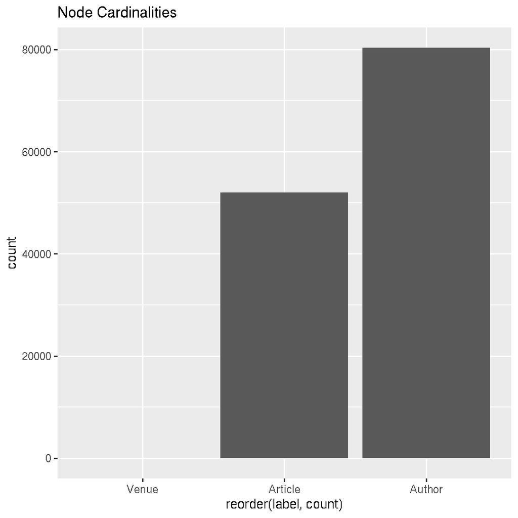

```r
ggplot(labResult, aes(x = reorder(label, count), y = count)) +
  geom_bar(stat = "identity")+
  ggtitle("Node Cardinalities")
```

## 1.5 Types of relationships: What types of relationships do we have in our graph?

```r
rr<-'CALL db.relationshipTypes()' %>% call_neo4j(con)
rul<-unlist(rr)
relResult<-data.frame(matrix(ncol=2, nrow = length(rul)))
colnames(relResult)<-c("relType", "count")

for (i in 1:length(rul))
{
  relType<- rul[i]
  query<- paste(" MATCH ()-[r:", relType , "]->() RETURN count(r) as count")
  rels <- query  %>%   call_neo4j(con)
  relResult$count[i]<-as.numeric(rels$count)
  relResult$relType[i]<-relType
}
relResult
```

```
##   relType  count
## 1   VENUE  51956
## 2  AUTHOR 140575
## 3   CITED  28706
```

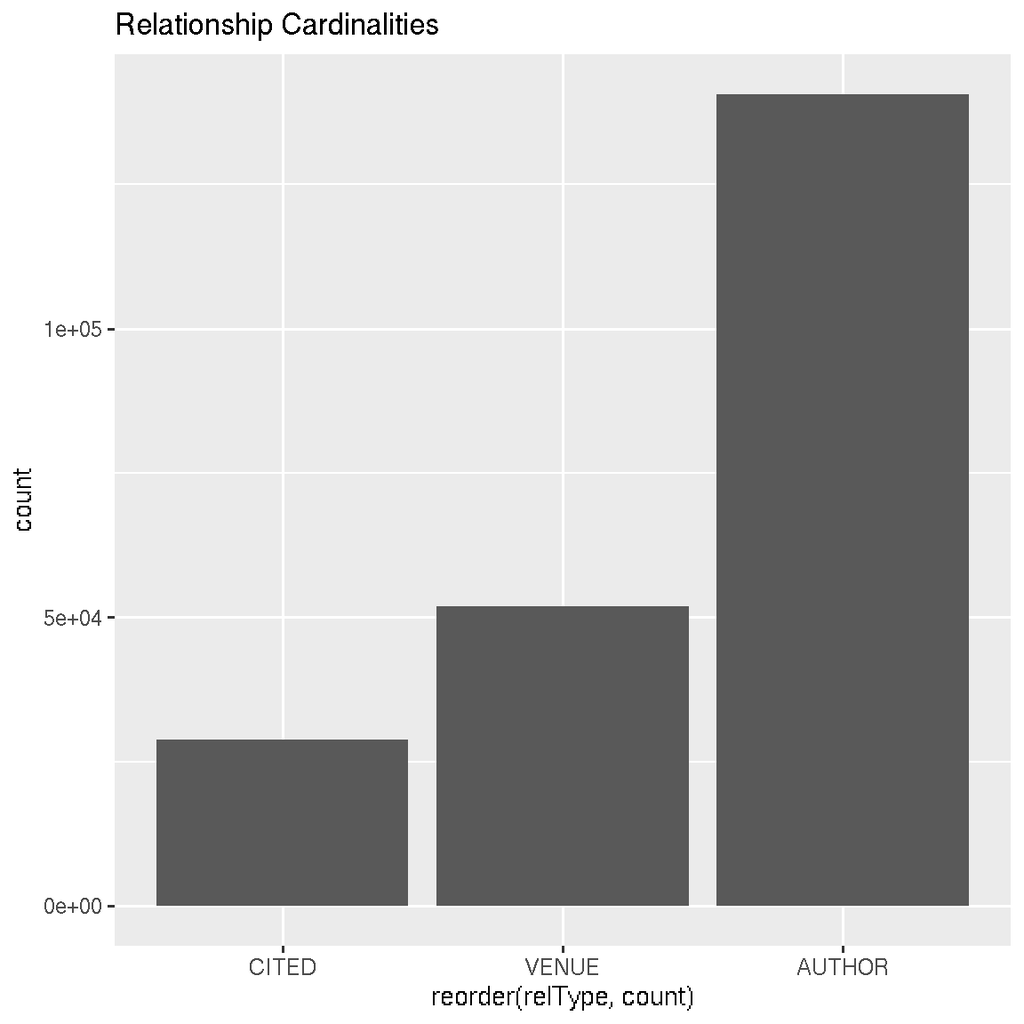

```r
ggplot(relResult, aes(x = reorder(relType, count), y = count)) +
  geom_bar(stat = "identity")+
  ggtitle("Relationship Cardinalities")
```

## 1.6 Explore the citation data.

The following query finds 25 authors, articles, venues, and also shows the number of articles that article has cited, as well as the number of articles that it’s been cited by

```r
dd<-as.data.frame(
'MATCH (author:Author)<-[:AUTHOR]-(article:Article)-[:VENUE]->(venue)
RETURN article.title AS article,
author.name AS author,
venue.name AS venue,
size((article)-[:CITED]->()) AS citationsGiven,
size((article)<-[:CITED]-()) AS citationsReceived
ORDER BY rand() LIMIT 25'  %>%   call_neo4j(con))
colnames(dd)<-c("title","author",
                "articles","citationsGiven","citationsReceived")
knitr::kable(dd[1:5,], format="pandoc")
```

| title | author | articles | citationsGiven | citationsReceived |
| --- | --- | --- | --- | --- |
| Modeling Multiple Interactions Using Coloured Petri Nets: A Case Study | Francisco Camargo-Santacruz | Lecture Notes in Computer Science | 1 | 0 |
| Requirement) evolution requirements for adaptive systems | John Mylopoulos | international conference on software engineering | 1 | 3 |
| Exploring personal information | Susan T. Dumais | Communications of The ACM | 0 | 0 |
| De-noising of ultrasound image using discrete wavelet transform by symlet wavelet and filters | Ashwani Kumar Yadav | advances in computing and communications | 0 | 0 |
| ATM connection and traffic management schemes for multimedia internetworking | Atsushi Iwata | Communications of The ACM | 0 | 1 |

## 1.7 Citation data more closely.

```r
numbers<-as.data.frame('MATCH (a:Article) RETURN size((a)<-[:CITED]-()) AS citations' %>%   call_neo4j(con))

print(summary(numbers$value))
```

```
##     Min.  1st Qu.   Median     Mean  3rd Qu.     Max.
##   0.0000   0.0000   0.0000   0.5525   0.0000 211.0000
```

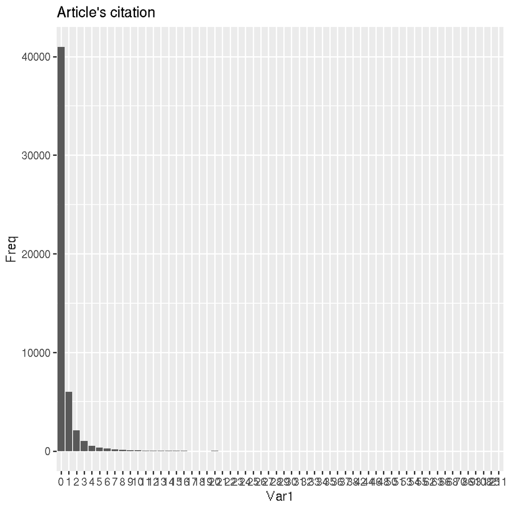

```r
nn<-as.data.frame(table(numbers$value))
ggplot(nn, aes(x = Var1, y = Freq)) +
  geom_bar(stat = "identity")+
  ggtitle("Article's citation")
```

## 1.8 Exercise instructions

- Create a similar query showing the articles that cite the most other papers? Note that you’ll only need to do a slight tweak of the Cypher query to do this.

slight tweak of the Cypher : (deberia ser la direccion de la flechaS)

```r
numbers<-as.data.frame('MATCH (a:Article) RETURN size((a)-[:CITED]->()) AS citations' %>%   call_neo4j(con))

print(summary(numbers$value))
```

```
##    Min. 1st Qu.  Median    Mean 3rd Qu.    Max.
##  0.0000  0.0000  0.0000  0.5525  1.0000 51.0000
```

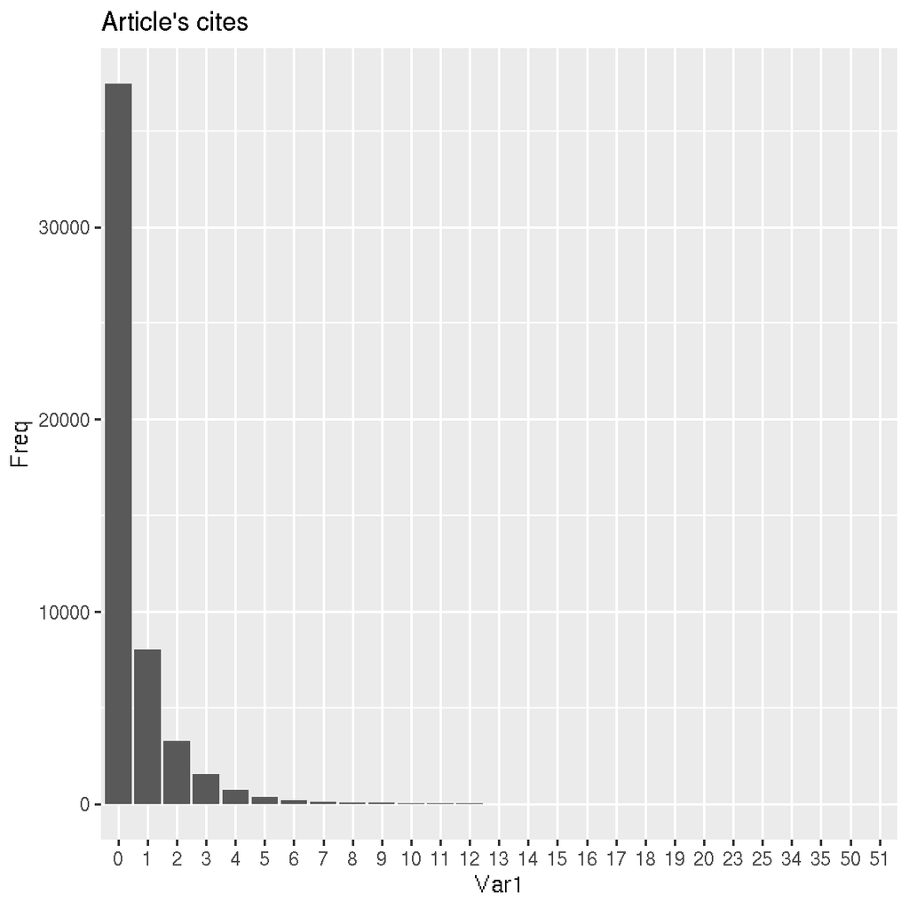

```r
cc<-as.data.frame(table(numbers$value))
ggplot(cc, aes(x = Var1, y = Freq)) +
  geom_bar(stat = "identity")+
  ggtitle("Article's cites")
```

- What about a distribution of the number of articles published by authors?

```r
published<-as.data.frame('MATCH (a:Author) RETURN size((a)<-[:AUTHOR]-()) AS publications' %>%   call_neo4j(con))

print(summary(published$value))
```

```
##    Min. 1st Qu.  Median    Mean 3rd Qu.    Max.
##   1.000   1.000   1.000   1.751   2.000  89.000
```

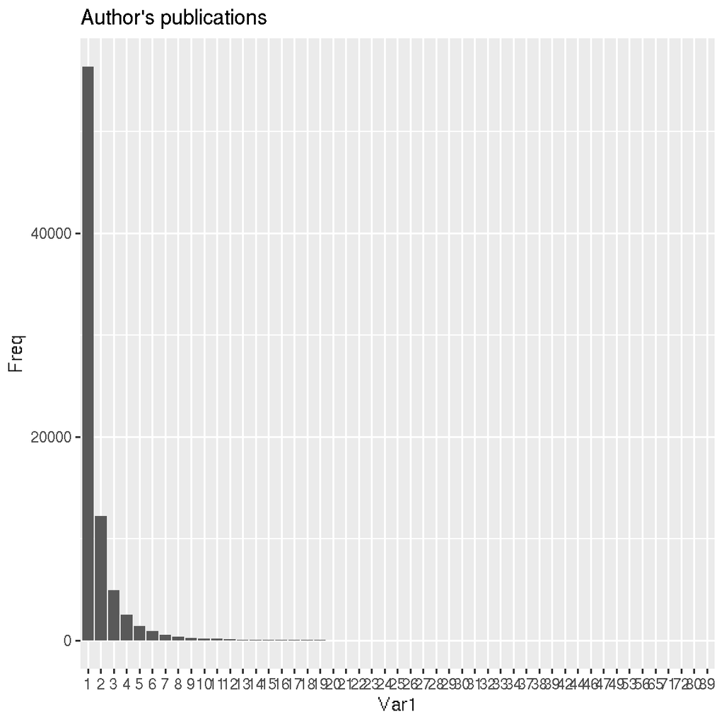

```r
pp<-as.data.frame(table(published$value))
ggplot(pp, aes(x = Var1, y = Freq)) +
  geom_bar(stat = "identity")+
  ggtitle("Author's publications")
```